# Project Machine Learning group

### Group Members 3

**Mareme Soda DIOP**

**Mairame Samba Niang**

**OKERE Rafiatou**

### The main goal of this Machine Learning project is to analyze the air quality data of a city.

We work on two important tasks: predicting the Air Quality Index (AQI) using regression, and detecting pollution with a binary classification model.

```python
#!pip install seaborn
```

```python
import pandas as pd
import numpy as np
import matplotlib.pyplot as plt
import seaborn as sns
from sklearn.preprocessing import StandardScaler
```

```python
#LOAD THE DATA FOR TRAINING
train = pd.read_csv("D:/ISLP_labs/Projet_AIMS/data/training_data_AIMS.csv")
```

Before starting the work, we must clean the Train Dataset using different methods like this:

```python
train
```

|  | SO2 | CO | O3 | O3_8hr | PM10 | PM2.5 | NO2 | NOx | NO | WindSpeed | WindDirec | DataCreationDate | CO_8hr | PM2.5_AVG | PM10_AVG | SO2_AVG | AQI | Pollutant |
| --- | --- | --- | --- | --- | --- | --- | --- | --- | --- | --- | --- | --- | --- | --- | --- | --- | --- | --- |
| 0 | 5.2 | 0.37 | 50.0 | 80 | 51 | 29 | 19.0 | 21.0 | 1.6 | 2.1 | E | 9/28/2017 16:00 | 0.5 | 37 | 60 | 5 | 128.0 | 1 |
| 1 | 4.6 | 0.25 | 72.0 | 68 | 46 | 21 | 12.0 | 14.0 | 1.2 | 3.7 | N | 9/28/2017 16:00 | 0.4 | 30 | 57 | 5 | 100.0 | 1 |
| 2 | 3.8 | 0.29 | 74.0 | 59 | 56 | 39 | 7.7 | 8.8 | 1.1 | 2.4 | W | 9/28/2017 15:00 | 0.4 | 32 | 55 | 4 | 96.0 | 1 |
| 3 | 1.8 | 0.17 | 51.0 | 50 | 36 | 23 | 3.3 | 4.8 | 1.5 | 2.7 | W | 9/28/2017 15:00 | 0.3 | 27 | 44 | 2 | 83.0 | 1 |
| 4 | 2.6 | 0.12 | 33.0 | 31 | 33 | 22 | 4.5 | 5.4 | 1.0 | 2.7 | W | 9/28/2017 15:00 | 0.2 | 22 | 39 | 3 | 75.0 | 1 |
| ... | ... | ... | ... | ... | ... | ... | ... | ... | ... | ... | ... | ... | ... | ... | ... | ... | ... | ... |
| 70787 | 8.0 | 0.70 | 3.5 | 19 | 31 | 5 | 30.0 | 36.0 | 6.3 | 1.1 | E | 8/28/2018 0:00 | 0.5 | 8 | 27 | 5 | 30.0 | 0 |
| 70788 | 1.4 | 0.21 | 22.0 | 23 | 20 | 10 | 11.0 | 12.0 | 0.5 | 0.9 | N | 8/28/2018 0:00 | 0.3 | 10 | 18 | 2 | 36.0 | 0 |
| 70789 | 2.0 | 0.29 | 7.7 | 14 | 45 | 17 | 13.0 | 15.0 | 2.6 | 0.6 | N | 8/28/2018 0:00 | 0.5 | 14 | 42 | 2 | 42.0 | 0 |
| 70790 | 1.9 | 0.18 | 8.2 | 26 | 16 | 9 | 12.0 | 15.0 | 2.6 | 2.0 | N | 8/28/2018 0:00 | 0.2 | 7 | 15 | 2 | 22.0 | 0 |
| 70791 | 2.1 | 0.35 | 5.6 | 16 | 14 | 3 | 20.0 | 22.0 | 1.7 | 1.8 | S | 8/28/2018 0:00 | 0.4 | 7 | 14 | 1 | 21.0 | 0 |

70792 rows × 18 columns

```python
#THE DIMENSION FOR TRAIN
train.shape
```

```
(70792, 18)
```

```python
#THE TYPES
train.dtypes
```

```
SO2                 float64
CO                  float64
O3                  float64
O3_8hr                int64
PM10                  int64
PM2.5                 int64
NO2                 float64
NOx                 float64
NO                  float64
WindSpeed           float64
WindDirec            object
DataCreationDate     object
CO_8hr              float64
PM2.5_AVG             int64
PM10_AVG              int64
SO2_AVG               int64
AQI                 float64
Pollutant             int64
dtype: object
```

We remark that The colums DateCreationDate is object, let's convert in datatime using the methods "to_datetime"

```python
train['DataCreationDate'] = pd.to_datetime(train['DataCreationDate'], errors='coerce')
```

```python
train.dtypes
```

```
SO2                        float64
CO                         float64
O3                         float64
O3_8hr                       int64
PM10                         int64
PM2.5                        int64
NO2                        float64
NOx                        float64
NO                         float64
WindSpeed                  float64
WindDirec                   object
DataCreationDate    datetime64[ns]
CO_8hr                     float64
PM2.5_AVG                    int64
PM10_AVG                     int64
SO2_AVG                      int64
AQI                        float64
Pollutant                    int64
dtype: object
```

```python
train.columns
```

```
Index(['SO2', 'CO', 'O3', 'O3_8hr', 'PM10', 'PM2.5', 'NO2', 'NOx', 'NO',
       'WindSpeed', 'WindDirec', 'DataCreationDate', 'CO_8hr', 'PM2.5_AVG',
       'PM10_AVG', 'SO2_AVG', 'AQI', 'Pollutant'],
      dtype='object')
```

The columns of the data set contain the 18 variables.

```python
train.describe()
```

|  | SO2 | CO | O3 | O3_8hr | PM10 | PM2.5 | NO2 | NOx | NO | WindSpeed | DataCreationDate | CO_8hr | PM2.5_AVG | PM10_AVG | SO2_AVG | AQI | Pollutant |
| --- | --- | --- | --- | --- | --- | --- | --- | --- | --- | --- | --- | --- | --- | --- | --- | --- | --- |
| count | 70792.000000 | 70792.000000 | 70792.000000 | 70792.000000 | 70792.000000 | 70792.000000 | 70792.000000 | 70792.000000 | 70792.00000 | 70792.000000 | 70792 | 70792.000000 | 70792.000000 | 70792.000000 | 70792.000000 | 67253.000000 | 70792.000000 |
| mean | 2.832851 | 0.367273 | 30.860401 | 31.014055 | 46.599559 | 21.049624 | 12.956475 | 16.075465 | 3.12598 | 2.482343 | 2018-03-12 07:28:43.771047424 | 0.366102 | 21.003320 | 46.532871 | 2.854899 | 64.786478 | 0.586493 |
| min | 0.000000 | 0.000000 | 0.000000 | 0.000000 | 1.000000 | 2.000000 | 0.000000 | 0.100000 | 0.00000 | 0.000000 | 2017-09-28 15:00:00 | 0.000000 | 1.000000 | 5.000000 | 0.000000 | 2.000000 | 0.000000 |
| 25% | 1.600000 | 0.220000 | 16.000000 | 19.000000 | 26.000000 | 11.000000 | 6.500000 | 7.900000 | 0.80000 | 1.300000 | 2017-12-21 22:00:00 | 0.200000 | 11.000000 | 27.000000 | 2.000000 | 39.000000 | 0.000000 |
| 50% | 2.300000 | 0.320000 | 29.000000 | 30.000000 | 40.000000 | 18.000000 | 11.000000 | 13.000000 | 1.50000 | 2.000000 | 2018-03-11 09:00:00 | 0.300000 | 18.000000 | 40.000000 | 3.000000 | 58.000000 | 1.000000 |
| 75% | 3.400000 | 0.450000 | 42.000000 | 41.000000 | 60.000000 | 28.000000 | 17.000000 | 20.000000 | 3.00000 | 3.100000 | 2018-05-31 17:00:00 | 0.400000 | 28.000000 | 60.000000 | 3.000000 | 84.000000 | 1.000000 |
| max | 78.000000 | 7.530000 | 131.000000 | 107.000000 | 869.000000 | 136.000000 | 73.000000 | 219.000000 | 170.00000 | 19.000000 | 2018-08-28 03:00:00 | 4.300000 | 122.000000 | 570.000000 | 60.000000 | 459.000000 | 1.000000 |
| std | 2.145733 | 0.226889 | 18.617066 | 16.008814 | 29.850135 | 14.547739 | 8.801246 | 12.747082 | 5.85614 | 1.812649 | NaN | 0.195651 | 13.293012 | 27.139107 | 1.425206 | 33.486748 | 0.492466 |

```python
print(train.isnull().sum())
```

```
SO2                    0
CO                     0
O3                     0
O3_8hr                 0
PM10                   0
PM2.5                  0
NO2                    0
NOx                    0
NO                     0
WindSpeed              0
WindDirec              0
DataCreationDate       0
CO_8hr                 0
PM2.5_AVG              0
PM10_AVG               0
SO2_AVG                0
AQI                 3539
Pollutant              0
dtype: int64
```

We notice that our dataset contains 3,539 missing values for AQI. To address this issue, we plan to use matrix completion via Principal Components using the SVD algorithm to approximate the missing entries.

Step1: Select the numerical coloums and create the matrix X with NaN

```python
# Select the numeric columns we want to impute
cols_numeric = ['AQI', 'PM10', 'PM2.5', 'NO2', 'SO2', 'CO', 'O3',
                 'WindSpeed', 'PM10_AVG', 'PM2.5_AVG', 'SO2_AVG', 'CO_8hr', 'O3_8hr', 'NOx', 'NO']
```

Creation of matrix whith the NaN

```python
X_raw = train[cols_numeric].values
X_raw
```

```
array([[128. ,  51. ,  29. , ...,  80. ,  21. ,   1.6],
       [100. ,  46. ,  21. , ...,  68. ,  14. ,   1.2],
       [ 96. ,  56. ,  39. , ...,  59. ,   8.8,   1.1],
       ...,
       [ 42. ,  45. ,  17. , ...,  14. ,  15. ,   2.6],
       [ 22. ,  16. ,   9. , ...,  26. ,  15. ,   2.6],
       [ 21. ,  14. ,   3. , ...,  16. ,  22. ,   1.7]])
```

# Step2: Standardisation

We need to center and scale. Because there are NaNs, the standard scaler might fail. We calculate the mean and standard deviation, ignoring the NaNs.

```python
# Compute column-wise mean and standard deviation
means = np.nanmean(X_raw, axis=0)
stds = np.nanstd(X_raw, axis=0)
```

```python
# Standardize the data
X_scaled = (X_raw - means) / stds
X_scaled
```

```
array([[ 1.8877316 ,  0.14741883,  0.54650635, ...,  3.05995743,
         0.38632922, -0.26057971],
       [ 1.05157372, -0.02008579, -0.00341116, ...,  2.31036508,
        -0.16281997, -0.32888457],
       [ 0.93212259,  0.31492344,  1.23390324, ...,  1.74817083,
        -0.57075936, -0.34596079],
       ...,
       [-0.68046761, -0.05358671, -0.27836991, ..., -1.06280046,
        -0.08437008, -0.08981754],
       [-1.27772324, -1.02511348, -0.82828742, ..., -0.31320812,
        -0.08437008, -0.08981754],
       [-1.30758603, -1.09211533, -1.24072555, ..., -0.93786841,
         0.4647791 , -0.24350349]])
```

```python
# using Singular Value Decomposition (SVD)
def low_rank(X, M=1):
    U, D, V = np.linalg.svd(X, full_matrices=False)
    L = U[:,:M] * D[None,:M]
    return L.dot(V[:M])
```

```python
# Replace missing values in X_scaled with 0
ismiss = np.isnan(X_scaled)
```

```python
Xhat = X_scaled.copy()
Xhat[ismiss] = 0
```

```python
# Parameters for the iterative matrix completion algorithm
thresh = 1e-5
rel_err = 1
count = 0
mssold = np.mean(Xhat[~ismiss]**2)
mss0 = np.mean(X_scaled[~ismiss]**2)
n_components = 5
```

```python
# Iterative SVD Matrix Completion
print("Starting iterative imputation.")

while rel_err > thresh:
    count += 1
     # Step 2(a): Low-rank approximation using SVD (PCA)
    Xapp = low_rank(Xhat, M=n_components)

    # Step 2(b): Update ONLY the missing values
    Xhat[ismiss] = Xapp[ismiss]
    # Step 2(c): Compute relative error on observed (non-missing) entries
    mss = np.mean(((X_scaled - Xapp)[~ismiss])**2)
    rel_err = (mssold - mss) / mss0
    mssold = mss

    print(f"Iteration: {count}, Rel.Err: {rel_err:.2e}")

print("Convergence reached.")
```

```
Starting iterative imputation.
Iteration: 1, Rel.Err: 8.46e-01
Iteration: 2, Rel.Err: 4.93e-04
Iteration: 3, Rel.Err: 2.60e-05
Iteration: 4, Rel.Err: 1.49e-06
Convergence reached.
```

```python
# by multiplying with the original standard deviations and adding the means

X_final = (Xhat * stds) + means
X_final
```

```
array([[128. ,  51. ,  29. , ...,  80. ,  21. ,   1.6],
       [100. ,  46. ,  21. , ...,  68. ,  14. ,   1.2],
       [ 96. ,  56. ,  39. , ...,  59. ,   8.8,   1.1],
       ...,
       [ 42. ,  45. ,  17. , ...,  14. ,  15. ,   2.6],
       [ 22. ,  16. ,   9. , ...,  26. ,  15. ,   2.6],
       [ 21. ,  14. ,   3. , ...,  16. ,  22. ,   1.7]])
```

```python
train['AQI'] = X_final[:, 0]
```

```python
# Final check
print(f"There are {train['AQI'].isnull().sum()} missing values remaining.")
```

```
There are 0 missing values remaining.
```

```python
train.isnull().sum()
```

```
SO2                 0
CO                  0
O3                  0
O3_8hr              0
PM10                0
PM2.5               0
NO2                 0
NOx                 0
NO                  0
WindSpeed           0
WindDirec           0
DataCreationDate    0
CO_8hr              0
PM2.5_AVG           0
PM10_AVG            0
SO2_AVG             0
AQI                 0
Pollutant           0
dtype: int64
```

Now about the missing values is good now.Let's verify now the duplicated

```python
train.duplicated().sum()
```

```
0
```

We have also 0 duplicated about our dataset

```python
train['AQI']
```

```
0        128.0
1        100.0
2         96.0
3         83.0
4         75.0
         ...
70787     30.0
70788     36.0
70789     42.0
70790     22.0
70791     21.0
Name: AQI, Length: 70792, dtype: float64
```

## Now we finish the cleaning about our dataset. We want to do the exploratory analysis.

### Before running complex algorithms, let's create simple plots to answer the question: 'What patterns and trends do you observe?

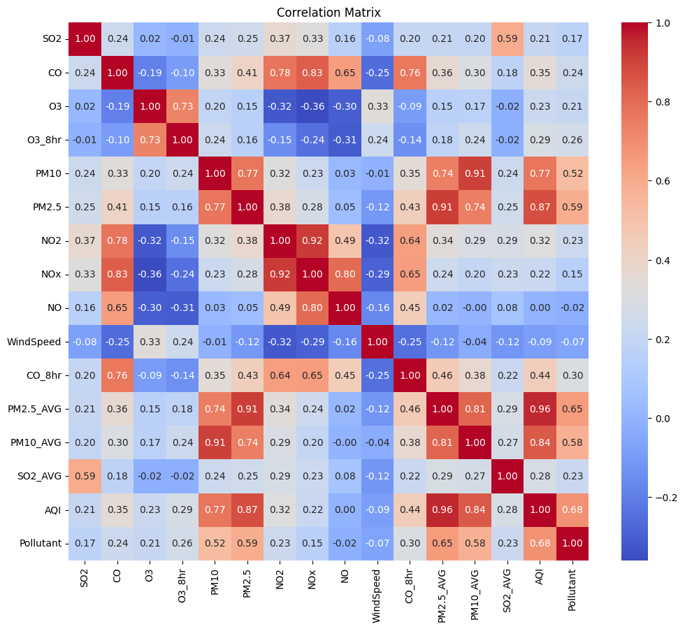

```python
matrice = train.corr(numeric_only=True)

plt.figure(figsize=(12, 10))
sns.heatmap(matrice, annot=True, cmap='coolwarm', fmt=".2f")
plt.title("Correlation Matrix")
plt.show()
```

#### Observation

We remark that the AQI is very strongly positively correlated with fine particulate matter. A correlation of 0.96 is observed with PM2.5_AVG and 0.87 with PM2.5. It is also strongly correlated with PM10 (0.77).

#### Interpretation

This suggests that in this city, air quality is primarily determined by the concentration of particles (dust, fumes), rather than by gases such as SO2 or Ozone.

#### Conclusion

The PM2.5 and PM10 variables will be our most powerful predictors, so we will use them for our prediction

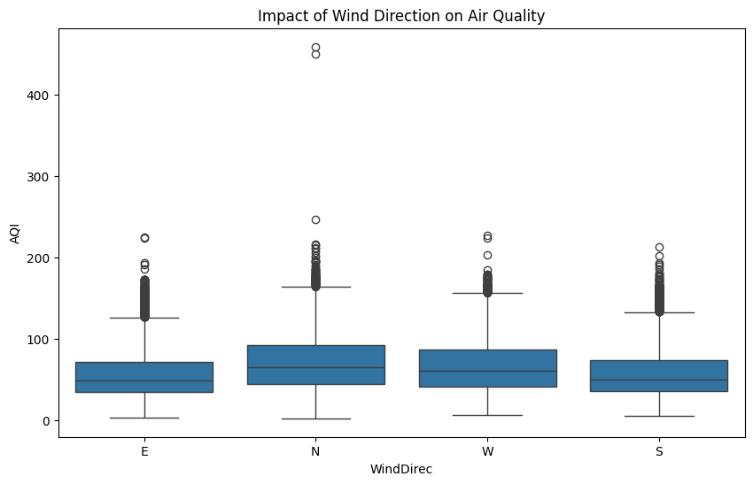

```python
#Specific analysis for wind (Categorical vs. Numerical Variable)
plt.figure(figsize=(10, 6))
sns.boxplot(x='WindDirec', y='AQI', data=train)
plt.title("Impact of Wind Direction on Air Quality")
plt.show()
```

```python
from sklearn.preprocessing import StandardScaler
features_clustering = ['PM10', 'PM2.5', 'NO2', 'SO2', 'CO', 'O3',
                       'WindSpeed', 'PM10_AVG', 'PM2.5_AVG']
X_cluster = train[features_clustering]

# 2. Standardisation
scaler = StandardScaler()
X_scaled = scaler.fit_transform(X_cluster)
```

```
Research of optimal K..
```

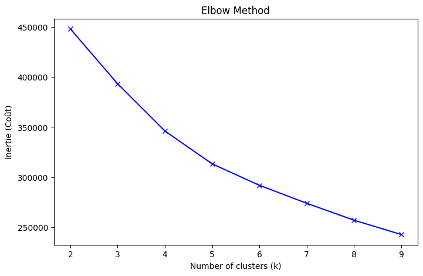

```python
from sklearn.cluster import KMeans

inertias = []
K_range = range(2, 10)

print("Research of optimal K..")
for k in K_range:
    kmeans = KMeans(n_clusters=k, random_state=42, n_init=10)
    kmeans.fit(X_scaled)
    inertias.append(kmeans.inertia_)

plt.figure(figsize=(8, 5))
plt.plot(K_range, inertias, 'bx-')
plt.xlabel('Number of clusters (k)')
plt.ylabel('Inertie (Coût)')
plt.title('Elbow Method')
plt.show()
```

### Interpretation

We can choose K = 4 because the curve drops sharply. This means each new cluster adds important information and helps separate very different groups

```python
k_optimal = 4

print(f"Launch of K-Means with {k_optimal} clusters...")
kmeans_final = KMeans(n_clusters=k_optimal, random_state=42, n_init=10)

train['Cluster'] = kmeans_final.fit_predict(X_scaled)

resultat = train.groupby('Cluster')[features_clustering + ['AQI']].agg(['mean', 'count'])

display(resultat.T)
```

```
Launch of K-Means with 4 clusters...
```

|  | Cluster | 0 | 1 | 2 | 3 |
| --- | --- | --- | --- | --- | --- |
| PM10 | mean | 44.847595 | 27.026357 | 59.057425 | 100.477778 |
|  | count | 13077.000000 | 32439.000000 | 16996.000000 | 8280.000000 |
| PM2.5 | mean | 21.176875 | 11.280681 | 26.151506 | 48.648551 |
|  | count | 13077.000000 | 32439.000000 | 16996.000000 | 8280.000000 |
| NO2 | mean | 23.408534 | 8.354413 | 9.750794 | 21.058949 |
|  | count | 13077.000000 | 32439.000000 | 16996.000000 | 8280.000000 |
| SO2 | mean | 3.840621 | 2.108157 | 2.889256 | 3.964626 |
|  | count | 13077.000000 | 32439.000000 | 16996.000000 | 8280.000000 |
| CO | mean | 0.594126 | 0.248551 | 0.321307 | 0.568470 |
|  | count | 13077.000000 | 32439.000000 | 16996.000000 | 8280.000000 |
| O3 | mean | 16.833762 | 27.086131 | 49.809538 | 28.903925 |
|  | count | 13077.000000 | 32439.000000 | 16996.000000 | 8280.000000 |
| WindSpeed | mean | 1.520930 | 2.632452 | 3.221958 | 1.894481 |
|  | count | 13077.000000 | 32439.000000 | 16996.000000 | 8280.000000 |
| PM10_AVG | mean | 44.610155 | 28.423009 | 58.682337 | 95.580797 |
|  | count | 13077.000000 | 32439.000000 | 16996.000000 | 8280.000000 |
| PM2.5_AVG | mean | 20.640820 | 11.969235 | 26.395034 | 45.901812 |
|  | count | 13077.000000 | 32439.000000 | 16996.000000 | 8280.000000 |
| AQI | mean | 63.436217 | 41.088788 | 81.646483 | 125.298901 |
|  | count | 13077.000000 | 32439.000000 | 16996.000000 | 8280.000000 |

### Interpretation

Cluster #1 (The majority group, N = 32,439): “Clean Air Days” PM10 = 27 (lowest)

NO2 = 8.3 (lowest)

CO = 0.24 (lowest)

These are days when weather conditions (like wind or rain) help clean the air. It represents the “normal” and healthy situation.

Cluster #3 (The small critical group, N = 8,280): “Heavy Pollution Days”

PM10 = 100 (extremely high)

PM2.5 = 48 (very high)

CO & SO2 are also high.

Interpretation: These are severe pollution episodes when all pollutants build up, likely because there is no wind or there is a temperature inversion.

Cluster #0 (N = 13,077): “Urban / Traffic Pollution”

There is an interesting contrast:

CO (0.59) and NO2 (23.4) are as high as in the “Smog” cluster (#3).

BUT PM10 = 44 is moderate and much lower than in cluster #3.

Interpretation: CO and NO2 are typical exhaust gases from vehicles. This cluster probably represents rush hours or days with heavy road traffic, but without dust storms.

Cluster #2 (N = 16,996): “Dust Pollution (PM)”

This is the opposite of cluster #0:

PM10 is high (59), much higher than in cluster #0.

BUT NO2 (9.7) and CO (0.32) are very low, almost like clean-air days.

Interpretation: This means dust without exhaust gases. It is typical of natural dust: sand winds, construction sites, or unpaved roads.

### Conclusion

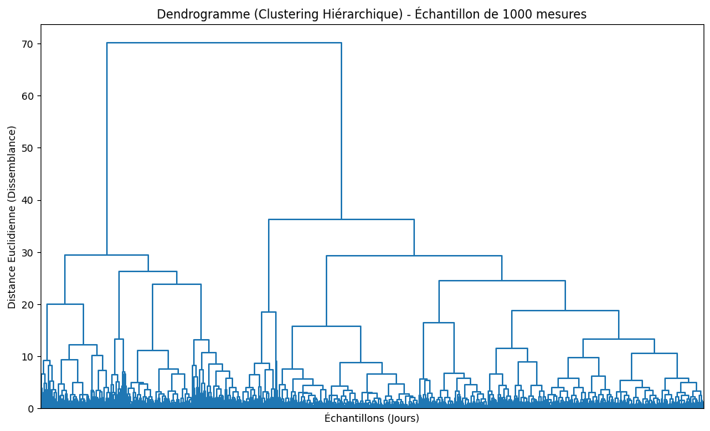

```python
import matplotlib.pyplot as plt
import scipy.cluster.hierarchy as sch
import numpy as np

indices_aleatoires = np.random.choice(X_scaled.shape[0], 1000, replace=False)
X_sample = X_scaled[indices_aleatoires]

Z = sch.linkage(X_sample, method='ward')
plt.figure(figsize=(12, 7))
plt.title("Dendrogramme (Clustering Hiérarchique) - Échantillon de 1000 mesures")
plt.xlabel('Échantillons (Jours)')
plt.ylabel('Distance Euclidienne (Dissemblance)')
dendrogram = sch.dendrogram(
    Z,
    leaf_rotation=90.,
    leaf_font_size=8.,
    no_labels=True,
    color_threshold=0
)



plt.show()
```

```python
#installation of mlxtend
#!pip install mlxtend
```

```python
import pandas as pd
from sklearn.linear_model import LinearRegression
from sklearn.model_selection import train_test_split
from sklearn.metrics import mean_squared_error
from mlxtend.feature_selection import SequentialFeatureSelector as SFS
from sklearn.preprocessing import StandardScaler

Y = train['AQI']

X_cols = ['PM10', 'PM2.5', 'NO2', 'SO2', 'CO', 'O3', 'WindSpeed',
          'PM10_AVG', 'PM2.5_AVG', 'SO2_AVG', 'CO_8hr', 'O3_8hr', 'NOx', 'NO']
X = train[X_cols]

X_train, X_val, Y_train, Y_val = train_test_split(X, Y, test_size=0.2, random_state=42)
scaler = StandardScaler()
X_train_scaled = scaler.fit_transform(X_train)
X_val_scaled = scaler.transform(X_val)
X_train_scaled_df = pd.DataFrame(X_train_scaled, columns=X_cols)
X_val_scaled_df = pd.DataFrame(X_val_scaled, columns=X_cols)
```

```python
print(" Launch of Forward Selection (SFS) ")

sfs_forward = SFS(
    LinearRegression(),
    k_features='best',
    forward=True,
    floating=False,
    scoring='neg_mean_squared_error',
    cv=5
)

sfs_forward = sfs_forward.fit(X_train_scaled_df, Y_train)

print("\n All subsets tested ")

for k, v in sfs_forward.subsets_.items():
    print(f"\nSous-ensemble de taille {k} : {v['feature_names']}")
    print(f"MSE CV = {-v['avg_score']:.4f}")

forward_features = list(sfs_forward.k_feature_names_)
forward_score = -sfs_forward.k_score_
print("\nMeilleur sous-ensemble (Forward) par CV-MSE:")
print(f"Features ({len(forward_features)}): {forward_features}")
print(f"MSE de Validation Croisée pour ce sous-ensemble : {forward_score:.3f}")
```

```
 Launch of Forward Selection (SFS)

 All subsets tested

Sous-ensemble de taille 1 : ('PM2.5_AVG',)
MSE CV = 95.9129

Sous-ensemble de taille 2 : ('PM2.5_AVG', 'O3_8hr')
MSE CV = 81.6563

Sous-ensemble de taille 3 : ('PM10_AVG', 'PM2.5_AVG', 'O3_8hr')
MSE CV = 71.2965

Sous-ensemble de taille 4 : ('PM10_AVG', 'PM2.5_AVG', 'CO_8hr', 'O3_8hr')
MSE CV = 70.7529

Sous-ensemble de taille 5 : ('PM10_AVG', 'PM2.5_AVG', 'CO_8hr', 'O3_8hr', 'NO')
MSE CV = 70.6351

Sous-ensemble de taille 6 : ('O3', 'PM10_AVG', 'PM2.5_AVG', 'CO_8hr', 'O3_8hr', 'NO')
MSE CV = 70.5290

Sous-ensemble de taille 7 : ('O3', 'WindSpeed', 'PM10_AVG', 'PM2.5_AVG', 'CO_8hr', 'O3_8hr', 'NO')
MSE CV = 70.3771

Sous-ensemble de taille 8 : ('O3', 'WindSpeed', 'PM10_AVG', 'PM2.5_AVG', 'SO2_AVG', 'CO_8hr', 'O3_8hr', 'NO')
MSE CV = 70.3258

Sous-ensemble de taille 9 : ('PM2.5', 'O3', 'WindSpeed', 'PM10_AVG', 'PM2.5_AVG', 'SO2_AVG', 'CO_8hr', 'O3_8hr', 'NO')
MSE CV = 70.3085

Sous-ensemble de taille 10 : ('PM2.5', 'CO', 'O3', 'WindSpeed', 'PM10_AVG', 'PM2.5_AVG', 'SO2_AVG', 'CO_8hr', 'O3_8hr', 'NO')
MSE CV = 70.3006

Sous-ensemble de taille 11 : ('PM2.5', 'CO', 'O3', 'WindSpeed', 'PM10_AVG', 'PM2.5_AVG', 'SO2_AVG', 'CO_8hr', 'O3_8hr', 'NOx', 'NO')
MSE CV = 70.3006

Sous-ensemble de taille 12 : ('PM2.5', 'NO2', 'CO', 'O3', 'WindSpeed', 'PM10_AVG', 'PM2.5_AVG', 'SO2_AVG', 'CO_8hr', 'O3_8hr', 'NOx', 'NO')
MSE CV = 70.3048

Sous-ensemble de taille 13 : ('PM2.5', 'NO2', 'SO2', 'CO', 'O3', 'WindSpeed', 'PM10_AVG', 'PM2.5_AVG', 'SO2_AVG', 'CO_8hr', 'O3_8hr', 'NOx', 'NO')
MSE CV = 70.3093

Sous-ensemble de taille 14 : ('PM10', 'PM2.5', 'NO2', 'SO2', 'CO', 'O3', 'WindSpeed', 'PM10_AVG', 'PM2.5_AVG', 'SO2_AVG', 'CO_8hr', 'O3_8hr', 'NOx', 'NO')
MSE CV = 70.4458

Meilleur sous-ensemble (Forward) par CV-MSE:
Features (10): ['PM2.5', 'CO', 'O3', 'WindSpeed', 'PM10_AVG', 'PM2.5_AVG', 'SO2_AVG', 'CO_8hr', 'O3_8hr', 'NO']
MSE de Validation Croisée pour ce sous-ensemble : 70.301
```

```python
# 3. BACKWARD Methode


print("\n Lancement du Backward Elimination (SBS)")

sbs_backward = SFS(
    LinearRegression(),
    k_features='best',
    forward=False,
    floating=False,
    scoring='neg_mean_squared_error',
    cv=5
)

sbs_backward = sbs_backward.fit(X_train_scaled_df, Y_train)

backward_features = list(sbs_backward.k_feature_names_)
backward_score = -sbs_backward.k_score_
print("\nMeilleur sous-ensemble (Backward) par CV-MSE:")
print(f"Features ({len(backward_features)}): {backward_features}")
print(f"MSE de Validation Croisée pour ce sous-ensemble : {backward_score:.3f}")
```

```
 Lancement du Backward Elimination (SBS)

Meilleur sous-ensemble (Backward) par CV-MSE:
Features (10): ['PM2.5', 'CO', 'O3', 'WindSpeed', 'PM10_AVG', 'PM2.5_AVG', 'SO2_AVG', 'CO_8hr', 'O3_8hr', 'NO']
MSE de Validation Croisée pour ce sous-ensemble : 70.301
```

We have the same MSE for both method(Forward and Backward) as 70.301 and the best subset is ['PM2.5', 'CO', 'O3', 'WindSpeed', 'PM10_AVG', 'PM2.5_AVG', 'SO2_AVG', 'CO_8hr', 'O3_8hr', 'NO']..

And now we will use the Lasso and Ridge on the dataset

```python
Y = train['AQI']

X_cols = ['PM10', 'PM2.5', 'NO2', 'SO2', 'CO', 'O3', 'WindSpeed',
          'PM10_AVG', 'PM2.5_AVG', 'SO2_AVG', 'CO_8hr', 'O3_8hr', 'NOx', 'NO']
X = train[X_cols]

X_train, X_val, Y_train, Y_val = train_test_split(X, Y, test_size=0.2, random_state=42)

scaler = StandardScaler()
X_train_scaled = scaler.fit_transform(X_train)
X_val_scaled = scaler.transform(X_val)
```

```python
from sklearn.linear_model import RidgeCV, LassoCV
print("--- Lancement de la Ridge Regression (Optimisation Alpha par CV) ---")

alphas = np.logspace(-4, 4, 100)

ridge_cv = RidgeCV(
    alphas=alphas,
    scoring='neg_mean_squared_error',
    cv=5
).fit(X_train_scaled, Y_train)

Y_pred_val_ridge = ridge_cv.predict(X_val_scaled)
mse_ridge = mean_squared_error(Y_val, Y_pred_val_ridge)
rmse_ridge = np.sqrt(mse_ridge)

print(f"Meilleur Alpha sélectionné (Ridge) : {ridge_cv.alpha_:.4f}")
print(f"MSE Ridge sur l'ensemble de VALIDATION : {mse_ridge:.3f}")
print(f"RMSE Ridge sur l'ensemble de VALIDATION : {rmse_ridge:.3f}")
```

```
--- Lancement de la Ridge Regression (Optimisation Alpha par CV) ---
Meilleur Alpha sélectionné (Ridge) : 25.9502
MSE Ridge sur l'ensemble de VALIDATION : 71.339
RMSE Ridge sur l'ensemble de VALIDATION : 8.446
```

We remark that the MSE of Ridge Regression is higher than Forward method, We can remove this method on my different method. So now we use the Lasso to see the behavior of this.

```python
#LASSO REGRESSION
print("\nLaunch of Lasso Regression (Alpha Optimization by CV)")

lasso_cv = LassoCV(
    alphas=alphas,
    cv=5,
    max_iter=70000,
    random_state=42
).fit(X_train_scaled, Y_train)

#prediction and evaluation
Y_pred_val_lasso = lasso_cv.predict(X_val_scaled)
mse_lasso = mean_squared_error(Y_val, Y_pred_val_lasso)
rmse_lasso = np.sqrt(mse_lasso)

print(f"Best Alpha selected (Lasso) : {lasso_cv.alpha_:.4f}")
print(f"MSE Lasso across the entire VALIDATION process : {mse_lasso:.3f}")
print(f"RMSE Lasso across the entire VALIDATION process : {rmse_lasso:.3f}")

# Coefficient Analysis
lasso_coefficients = pd.Series(lasso_cv.coef_, index=X_cols)
zero_coefs = lasso_coefficients[lasso_coefficients == 0].index.tolist()
print(f"Variables whose coefficient was set to zero by Lasso : {zero_coefs}")
```

```
Launch of Lasso Regression (Alpha Optimization by CV)
Best Alpha selected (Lasso) : 0.0464
MSE Lasso across the entire VALIDATION process : 71.390
RMSE Lasso across the entire VALIDATION process : 8.449
Variables whose coefficient was set to zero by Lasso : ['PM10', 'NO2', 'SO2', 'CO', 'NOx']
```

```python
import pandas as pd
import numpy as np
from sklearn.ensemble import RandomForestRegressor
from sklearn.model_selection import train_test_split, GridSearchCV
from sklearn.metrics import mean_squared_error
from sklearn.preprocessing import StandardScaler

Y = train['AQI']

X_cols = ['PM10', 'PM2.5', 'NO2', 'SO2', 'CO', 'O3', 'WindSpeed',
          'PM10_AVG', 'PM2.5_AVG', 'SO2_AVG', 'CO_8hr', 'O3_8hr', 'NOx', 'NO']
X = train[X_cols]

X_train, X_val, Y_train, Y_val = train_test_split(X, Y, test_size=0.2, random_state=42)

print(" Lancement de l'optimisation des hyperparamètres (GridSearchCV) pour Random Forest ")


rf = RandomForestRegressor(random_state=42)

param_grid = {
    'n_estimators': [100, 200],
    'max_depth': [5, 10, None],
    'min_samples_leaf': [1, 5],
    'max_features': [0.5, 0.7, 'sqrt']
}

grid_search = GridSearchCV(
    estimator=rf,
    param_grid=param_grid,
    scoring='neg_mean_squared_error',
    cv=3,
    n_jobs=-1,
    verbose=1
)

# Training on the entire training set
grid_search.fit(X_train, Y_train)


#  EVALUATION OF THE BEST MODEL


best_rf_model = grid_search.best_estimator_

print("\nMeilleurs Hyperparamètres trouvés :")
print(grid_search.best_params_)

# Prédiction sur l'ensemble de validation
Y_pred_val_rf = best_rf_model.predict(X_val)
mse_rf = mean_squared_error(Y_val, Y_pred_val_rf)
rmse_rf = np.sqrt(mse_rf)

print(f"\n*** MSE Random Forest sur l'ensemble de VALIDATION : {mse_rf:.3f} ***")
print(f"*** RMSE Random Forest sur l'ensemble de VALIDATION : {rmse_rf:.3f} ***")

feature_importances = pd.Series(best_rf_model.feature_importances_, index=X_cols).sort_values(ascending=False)

print("\nImportance des Variables (Insights pour le rapport) :")
print(feature_importances)
```

```
 Lancement de l'optimisation des hyperparamètres (GridSearchCV) pour Random Forest
Fitting 3 folds for each of 36 candidates, totalling 108 fits

Meilleurs Hyperparamètres trouvés :
{'max_depth': 10, 'max_features': 0.7, 'min_samples_leaf': 1, 'n_estimators': 200}

*** MSE Random Forest sur l'ensemble de VALIDATION : 25.074 ***
*** RMSE Random Forest sur l'ensemble de VALIDATION : 5.007 ***

Importance des Variables (Insights pour le rapport) :
PM2.5_AVG    0.660188
PM2.5        0.187631
PM10_AVG     0.097656
O3_8hr       0.031876
PM10         0.016886
O3           0.001973
CO_8hr       0.001191
WindSpeed    0.000893
SO2          0.000364
NO2          0.000358
CO           0.000322
NOx          0.000270
NO           0.000265
SO2_AVG      0.000127
dtype: float64
```

Here we remark that the MSE Random Forest is very slow than the MSE of Regression lineaire, Lasso, Ridge regression same things for Foward and Backward methods. So far, we can say that the random forest method is the best method.

Now, let's use the Boosting also.

```python
import pandas as pd
import numpy as np
from sklearn.ensemble import GradientBoostingRegressor
from sklearn.model_selection import train_test_split, GridSearchCV
from sklearn.metrics import mean_squared_error

Y = train['AQI']

X_cols = ['PM10', 'PM2.5', 'NO2', 'SO2', 'CO', 'O3', 'WindSpeed',
          'PM10_AVG', 'PM2.5_AVG', 'SO2_AVG', 'CO_8hr', 'O3_8hr', 'NOx', 'NO']
X = train[X_cols]

X_train, X_val, Y_train, Y_val = train_test_split(X, Y, test_size=0.2, random_state=42)


print("--- Lancement de l'optimisation des hyperparamètres (GridSearchCV) pour Gradient Boosting ---")

#model
gbr = GradientBoostingRegressor(random_state=42)

param_grid = {
    'n_estimators': [100, 200],
    'learning_rate': [0.05, 0.1, 0.2],
    'max_depth': [3, 5],
    'subsample': [0.7, 1.0]
}

# Initialiser GridSearchCV
grid_search_gbr = GridSearchCV(
    estimator=gbr,
    param_grid=param_grid,
    scoring='neg_mean_squared_error',
    cv=3,
    n_jobs=-1,
    verbose=1
)

# Treatment
grid_search_gbr.fit(X_train, Y_train)


best_gbr_model = grid_search_gbr.best_estimator_

print("\nMeilleurs Hyperparamètres trouvés pour Gradient Boosting :")
print(grid_search_gbr.best_params_)


Y_pred_val_gbr = best_gbr_model.predict(X_val)
mse_gbr = mean_squared_error(Y_val, Y_pred_val_gbr)
rmse_gbr = np.sqrt(mse_gbr)

print(f"\n*** MSE Gradient Boosting sur l'ensemble de VALIDATION : {mse_gbr:.3f} ***")
print(f"*** RMSE Gradient Boosting sur l'ensemble de VALIDATION : {rmse_gbr:.3f} ***")

feature_importances_gbr = pd.Series(best_gbr_model.feature_importances_, index=X_cols).sort_values(ascending=False)

print("\nImportance des Variables (Insights pour le rapport) :")
print(feature_importances_gbr)
```

```
--- Lancement de l'optimisation des hyperparamètres (GridSearchCV) pour Gradient Boosting ---
Fitting 3 folds for each of 24 candidates, totalling 72 fits

Meilleurs Hyperparamètres trouvés pour Gradient Boosting :
{'learning_rate': 0.05, 'max_depth': 5, 'n_estimators': 200, 'subsample': 0.7}

*** MSE Gradient Boosting sur l'ensemble de VALIDATION : 24.207 ***
*** RMSE Gradient Boosting sur l'ensemble de VALIDATION : 4.920 ***

Importance des Variables (Insights pour le rapport) :
PM2.5_AVG    0.937214
O3_8hr       0.034880
PM10_AVG     0.023750
PM10         0.001416
PM2.5        0.000686
WindSpeed    0.000680
NO2          0.000314
SO2          0.000282
O3           0.000230
CO           0.000164
NOx          0.000144
NO           0.000121
SO2_AVG      0.000062
CO_8hr       0.000057
dtype: float64
```

Analysis of Important Variables in the Gradient Boosting Model

All the other variables have very small importance (less than 4%). Pollutants like PM10, PM2.5, NO₂, SO₂, CO, and NOx have values close to zero. This means they do not add useful information once PM2.5_AVG is already included.

## Conclusion

In summary, the main reason is that the relationship between pollutants and air quality is naturally non-linear, and Gradient Boosting is very good at learning this kind of complex pattern.

Gradient Boosting is our best model for both tasks because it achieved the lowest RMSE (4.920) for AQI prediction and the highest accuracy (0.9687) for pollutant detection.

The key reason is that this model understands the complexity in our data. Unlike simple models that assume a straight (linear) relationship, Gradient Boosting uses many small decision trees that work together. It learns by correcting the mistakes of the previous tree, so it can capture the curved relationships and pollution thresholds that other models cannot detect.

```python
from sklearn.decomposition import PCA
from sklearn.linear_model import LinearRegression
from sklearn.model_selection import GridSearchCV, train_test_split
from sklearn.metrics import mean_squared_error
from sklearn.pipeline import Pipeline
from sklearn.preprocessing import StandardScaler
max_components = X_train_scaled.shape[1]
print("\n--- Lancement de la PLS (Optimisation du nombre de composantes k) ---")

from sklearn.cross_decomposition import PLSRegression
param_grid_pls = {
    'n_components': np.arange(1, max_components + 1)
}

# Initialize GridSearchCV for PLSRegression
# We don't need a pipeline here because PLSRegression does both steps
grid_search_pls = GridSearchCV(
    PLSRegression(),
    param_grid_pls,
    scoring='neg_mean_squared_error',
    cv=5,
    n_jobs=-1,
    verbose=1
)

# Treatment
grid_search_pls.fit(X_train_scaled, Y_train)

#Answer
best_k_pls = grid_search_pls.best_params_['n_components']
best_pls_model = grid_search_pls.best_estimator_

Y_pred_val_pls = best_pls_model.predict(X_val_scaled)
mse_pls = mean_squared_error(Y_val, Y_pred_val_pls)
rmse_pls = np.sqrt(mse_pls)

print(f"\nMeilleur nombre de composantes (k) PLS : {best_k_pls}")
print(f"*** RMSE PLS sur l'ensemble de VALIDATION : {rmse_pls:.3f} ***")
```

```
--- Lancement de la PLS (Optimisation du nombre de composantes k) ---
Fitting 5 folds for each of 14 candidates, totalling 70 fits

Meilleur nombre de composantes (k) PLS : 13
*** RMSE PLS sur l'ensemble de VALIDATION : 8.446 ***
```

```python
print("\n--- Synthèse des RMSE ---")
print(f"RMSE Gradient Boosting (Meilleur Actuel) : 4.920")
print(f"RMSE PLS : {rmse_pls:.3f}")
```

```
--- Synthèse des RMSE ---
RMSE Gradient Boosting (Meilleur Actuel) : 4.920
RMSE PLS : 8.446
```

## Logistique Regression

Here we want to do the predictions about the pollutant

```python
from sklearn.linear_model import LogisticRegressionCV
from sklearn.model_selection import train_test_split
from sklearn.metrics import accuracy_score, confusion_matrix
from sklearn.preprocessing import StandardScaler


Y_clf = train['Pollutant']

X_cols = ['PM10', 'PM2.5', 'NO2', 'SO2', 'CO', 'O3', 'WindSpeed',
          'PM10_AVG', 'PM2.5_AVG', 'SO2_AVG', 'CO_8hr', 'O3_8hr', 'NOx', 'NO']
X = train[X_cols]

X_train, X_val, Y_train_clf, Y_val_clf = train_test_split(X, Y_clf, test_size=0.2, random_state=42, stratify=Y_clf)

# Standardisation of data
scaler = StandardScaler()
X_train_scaled = scaler.fit_transform(X_train)
X_val_scaled = scaler.transform(X_val)
```

```python
# Methode of Lasso Logistic Regression

print("Launch of the Logistics Regression ")

log_reg_cv = LogisticRegressionCV(
    cv=5,
    random_state=42,
    penalty='l1',
    solver='liblinear',
    scoring='accuracy',
    n_jobs=-1,
    max_iter=1000
).fit(X_train_scaled, Y_train_clf)
```

```
Launch of the Logistics Regression
```

```python
best_log_reg = log_reg_cv

# Prediction and evaluation
Y_pred_val_log_reg = best_log_reg.predict(X_val_scaled)
accuracy_log_reg = accuracy_score(Y_val_clf, Y_pred_val_log_reg)

print(f"\nSelection of the best C : {best_log_reg.C_[0]:.4f}")
print(f"*** Accuracy Logistic Regression across the entire VALIDATION set : {accuracy_log_reg:.4f} ***")

# Coefficients close to zero have been eliminated.
log_reg_coefs = pd.Series(best_log_reg.coef_[0], index=X_cols)
important_features = log_reg_coefs[np.abs(log_reg_coefs) > 0.001].index.tolist()

print(f"\nVariables with a non-zero coefficient  : {important_features}")

# Affichage de la Matrice de Confusion (utile pour évaluer l'équilibre)
print("\nConfusion Matrix across the Validation Set:")
print(confusion_matrix(Y_val_clf, Y_pred_val_log_reg))
```

[output not shown]

The Logistic Regression model achieves an accuracy of 94.22% in predicting pollutant levels. The confusion matrix shows strong classification performance, with 5514 correct detections of low pollution and 7827 correct detections of high pollution. The model makes relatively few errors, with only 341 false alarms and 477 missed high-pollution events. Overall, the model is reliable and effective for pollutant classification.

```python
from sklearn.ensemble import RandomForestClassifier
from sklearn.model_selection import GridSearchCV
from sklearn.metrics import accuracy_score


X_train, X_val, Y_train_clf, Y_val_clf = train_test_split(X, Y_clf, test_size=0.2, random_state=42, stratify=Y_clf)


print("\n--- Launch of hyperparameter optimization for Random Forest Classifier ---")
```

```
--- Launch of hyperparameter optimization for Random Forest Classifier ---
```

```python
# Definition of modele
rf_clf = RandomForestClassifier(random_state=42)

param_grid_rf = {
    'n_estimators': [100, 200],
    'max_depth': [10, 20, None],
    'min_samples_leaf': [1, 5]
}


# scoring='accuracy'
grid_search_rf_clf = GridSearchCV(
    estimator=rf_clf,
    param_grid=param_grid_rf,
    scoring='accuracy',
    cv=3,
    n_jobs=-1,
    verbose=1
)
# Training on the entire training course
grid_search_rf_clf.fit(X_train, Y_train_clf)
```

```
Fitting 3 folds for each of 12 candidates, totalling 36 fits
```

```
GridSearchCV(cv=3, estimator=RandomForestClassifier(random_state=42), n_jobs=-1,
             param_grid={'max_depth': [10, 20, None],
                         'min_samples_leaf': [1, 5],
                         'n_estimators': [100, 200]},
             scoring='accuracy', verbose=1)
```

```python
best_rf_clf_model = grid_search_rf_clf.best_estimator_

print("\nBest Hyperparameters Found:")
print(grid_search_rf_clf.best_params_)

# Prediction on the validation set
Y_pred_val_rf_clf = best_rf_clf_model.predict(X_val)
accuracy_rf_clf = accuracy_score(Y_val_clf, Y_pred_val_rf_clf)

print(f"\n*** Accuracy Random Forest across the entire VALIDATION : {accuracy_rf_clf:.4f} ***")


# 4. INSIGHTS


feature_importances_clf = pd.Series(best_rf_clf_model.feature_importances_, index=X_cols).sort_values(ascending=False)

print("\nImportance of  Variables  :")
print(feature_importances_clf)
```

```
Best Hyperparameters Found:
{'max_depth': None, 'min_samples_leaf': 1, 'n_estimators': 200}

*** Accuracy Random Forest across the entire VALIDATION : 0.9687 ***

Importance of  Variables  :
PM2.5_AVG    0.433073
PM2.5        0.168386
PM10_AVG     0.157722
PM10         0.080325
O3_8hr       0.034976
CO_8hr       0.023055
O3           0.018163
CO           0.016943
NO2          0.012251
NO           0.011904
WindSpeed    0.011769
SO2          0.011604
NOx          0.011045
SO2_AVG      0.008784
dtype: float64
```

From my results, I see that fine particles (PM2.5 and PM2.5_AVG) are the most important variables. They represent more than 60% of the total importance, which means they are the strongest indicators when detecting pollution.

I also notice that PM10 particles play a bigger role in this model. Unlike the AQI regression model, where gases were almost irrelevant, here PM10 and PM10_AVG together represent about 23.8% of the importance. This shows that larger particles also help a lot in identifying when the air changes from “clean” to “polluted.”

Conclusion

Overall, my analysis shows that pollution detection is mainly driven by particles, especially PM2.5, followed by PM10. These particles are the strongest signals for detecting the change from Clean Air (0) to Polluted Air (1).

```python
#Methode of boosting
from sklearn.ensemble import GradientBoostingClassifier
from sklearn.model_selection import GridSearchCV
from sklearn.metrics import accuracy_score

print("\n--- Hyperparameter optimization launched for Gradient Boosting CLASSIFIER ---")

gbt_clf = GradientBoostingClassifier(random_state=42)

param_grid_gbt = {
    'n_estimators': [100, 200],
    'learning_rate': [0.05, 0.1, 0.2],
    'max_depth': [3, 5],
}




grid_search_gbt_clf = GridSearchCV(
    estimator=gbt_clf,
    param_grid=param_grid_gbt,
    scoring='accuracy',
    cv=3,
    n_jobs=-1,
    verbose=1
)

# Treatment on the training set
grid_search_gbt_clf.fit(X_train, Y_train_clf)
```

```
--- Hyperparameter optimization launched for Gradient Boosting CLASSIFIER ---
Fitting 3 folds for each of 12 candidates, totalling 36 fits
```

```
GridSearchCV(cv=3, estimator=GradientBoostingClassifier(random_state=42),
             n_jobs=-1,
             param_grid={'learning_rate': [0.05, 0.1, 0.2], 'max_depth': [3, 5],
                         'n_estimators': [100, 200]},
             scoring='accuracy', verbose=1)
```

```python
best_gbt_clf_model = grid_search_gbt_clf.best_estimator_

print("\nBest Hyperparameters Found for Gradient Boosting Classifier :")
print(grid_search_gbt_clf.best_params_)
# Prediction on the validation set
Y_pred_val_gbt_clf = best_gbt_clf_model.predict(X_val)
accuracy_gbt_clf = accuracy_score(Y_val_clf, Y_pred_val_gbt_clf)

print(f"\n*** Accuracy Gradient Boosting across the entire VALIDATION : {accuracy_gbt_clf:.4f} ***")

# 4. INSIGHTS
feature_importances_gbt_clf = pd.Series(best_gbt_clf_model.feature_importances_, index=X_cols).sort_values(ascending=False)

print("\nImportance of Variables  :")
print(feature_importances_gbt_clf)
```

```
Best Hyperparameters Found for Gradient Boosting Classifier :
{'learning_rate': 0.05, 'max_depth': 3, 'n_estimators': 100}

*** Accuracy Gradient Boosting across the entire VALIDATION : 0.9687 ***

Importance of Variables  :
PM2.5_AVG    0.938411
PM10_AVG     0.033196
O3_8hr       0.027082
NO2          0.000399
SO2          0.000284
WindSpeed    0.000188
PM2.5        0.000096
NO           0.000069
O3           0.000066
CO           0.000064
PM10         0.000063
CO_8hr       0.000061
NOx          0.000020
SO2_AVG      0.000000
dtype: float64
```

The Random Forest and Gradient Boosting models are equal in terms of Accuracy (0.9687) We choose Gradient Boosting like the best model

## Now, we want to use the best model to generate predictions on the test data.

```python
#prediction on new data
from sklearn.ensemble import GradientBoostingRegressor, GradientBoostingClassifier
from sklearn.preprocessing import StandardScaler
import numpy as np

# Definition of variables
X_cols = ['PM10', 'PM2.5', 'NO2', 'SO2', 'CO', 'O3', 'WindSpeed',
          'PM10_AVG', 'PM2.5_AVG', 'SO2_AVG', 'CO_8hr', 'O3_8hr', 'NOx', 'NO']

test_df = pd.read_csv('D:/ISLP_labs/Projet_AIMS/data/test_data.csv')
```

```python
X_train_full = train[X_cols]
Y_reg_full = train['AQI']
Y_clf_full = train['Pollutant']

X_test = test_df[X_cols]
```

```python
print("Final training of the Gradient Boosting Regressor.")

scaler = StandardScaler()
X_train_scaled = scaler.fit_transform(X_train_full)
X_test_scaled = scaler.transform(X_test)

gbr_final = GradientBoostingRegressor(
    n_estimators=200,
    learning_rate=0.05,
    max_depth=5,
    random_state=42
)
gbr_final.fit(X_train_scaled, Y_reg_full)

# Prediction
predictions_reg = gbr_final.predict(X_test_scaled)



print("Final Gradient Boosting Classifier Training...")


X_train_clf = X_train_full
X_test_clf = X_test

# Final GBC training with the best hyperparameters (n=100, lr=0.05, max_d=3)
gbc_final = GradientBoostingClassifier(
    n_estimators=100,
    learning_rate=0.05,
    max_depth=3,
    random_state=42
)
gbc_final.fit(X_train_clf, Y_clf_full)

# Prediction
predictions_clf = gbc_final.predict(X_test_clf)
```

```
Final training of the Gradient Boosting Regressor.
Final Gradient Boosting Classifier Training...
```

```python
# Creation of file predictions.csv
predictions_df = pd.DataFrame({
    'Regression Predictions': predictions_reg,
    'Classification Predictions': predictions_clf.astype(int)
})

predictions_df.to_csv('Predictions.csv', index=False)

print("\n!!! The file 'Predictions.csv' was successfully created!!!")
print("Models used: Regression: GBR (RMSE 4.920), Classification: GBC (Accuracy 0.9687)")
```

```
!!! The file 'Predictions.csv' was successfully created!!!
Models used: Regression: GBR (RMSE 4.920), Classification: GBC (Accuracy 0.9687)
```

# Boostraping

```python
from sklearn.ensemble import GradientBoostingRegressor
from sklearn.model_selection import train_test_split
from sklearn.metrics import mean_squared_error
from sklearn.utils import resample
from sklearn.preprocessing import StandardScaler
X = train[X_cols]
Y = train['AQI']

data_full = pd.concat([X, Y], axis=1)
GBR_PARAMS = {
    'n_estimators': 200,
    'learning_rate': 0.05,
    'max_depth': 5,
    'random_state': 42
}
N_BOOTSTRAPS = 100
MSE_BOOTSTRAP_RESULTS = []
```

```python
print(f" Launching {N_BOOTSTRAPS} Bootstrapping iterations")

for i in range(N_BOOTSTRAPS):
    train_bootstrapped = resample(data_full, replace=True, random_state=i)


    X_boot_train, X_boot_val, Y_boot_train, Y_boot_val = train_test_split(
        train_bootstrapped[X_cols],
        train_bootstrapped['AQI'],
        test_size=0.2,
        random_state=i
    )

    scaler = StandardScaler()
    X_boot_train_scaled = scaler.fit_transform(X_boot_train)
    X_boot_val_scaled = scaler.transform(X_boot_val)

    gbr_model = GradientBoostingRegressor(**GBR_PARAMS)
    gbr_model.fit(X_boot_train_scaled, Y_boot_train)

    Y_pred_boot_val = gbr_model.predict(X_boot_val_scaled)
    mse_i = mean_squared_error(Y_boot_val, Y_pred_boot_val)

    MSE_BOOTSTRAP_RESULTS.append(mse_i)

    if (i+1) % 20 == 0:
        print(f"  Iteration {i+1}/{N_BOOTSTRAPS} finish. MSE : {mse_i:.3f}")
```

```
 Launching 100 Bootstrapping iterations
  Iteration 20/100 finish. MSE : 34.063
  Iteration 40/100 finish. MSE : 32.571
  Iteration 60/100 finish. MSE : 22.188
  Iteration 80/100 finish. MSE : 22.299
  Iteration 100/100 finish. MSE : 21.957
```

```python
mse_distribution = np.array(MSE_BOOTSTRAP_RESULTS)

mean_estimated_mse = np.mean(mse_distribution)

lower_bound = np.percentile(mse_distribution, 2.5)
upper_bound = np.percentile(mse_distribution, 97.5)

print("\n Bootstrapping Results ")
print(f"Estimated MSE (Average Bootstraps) : {mean_estimated_mse:.3f}")
print(f"Estimated MSE (Average Bootstraps) : {np.sqrt(mean_estimated_mse):.3f}")

print(f"\n95% Confidence Interval for the True MSE Test :")
print(f"[{lower_bound:.3f}, {upper_bound:.3f}]")
```

```
 Bootstrapping Results
Estimated MSE (Average Bootstraps) : 22.769
Estimated MSE (Average Bootstraps) : 4.772

95% Confidence Interval for the True MSE Test :
[21.274, 28.126]
```

# Histogramme to see the best Model

```python
#compute the RMSE values for all models
rmse_lin_best = np.sqrt(70.301)
rmse_ridge = np.sqrt(71.339)
rmse_lasso = np.sqrt(71.390)
rmse_pls = 8.446
rmse_gbr = 4.920
rmse_rf = 5.007
```

```python
reg_results = pd.DataFrame({
    'Modèle': ['Linéaire (Sél.)', 'Ridge', 'Lasso', 'PLS', 'Random Forest', 'Gradient Boosting'],
    'RMSE': [rmse_lin_best, rmse_ridge, rmse_lasso, rmse_pls, rmse_rf, rmse_gbr]
}).sort_values(by='RMSE', ascending=False)
```

```python
accuracy_log_reg = 0.9422
accuracy_rf = 0.9687
accuracy_gbt = 0.9687

clf_results = pd.DataFrame({
    'Model': ['Logistic Regression', 'Random Forest', 'Gradient Boosting'],
    'Accuracy': [accuracy_log_reg, accuracy_rf, accuracy_gbt]
}).sort_values(by='Accuracy', ascending=False)
```

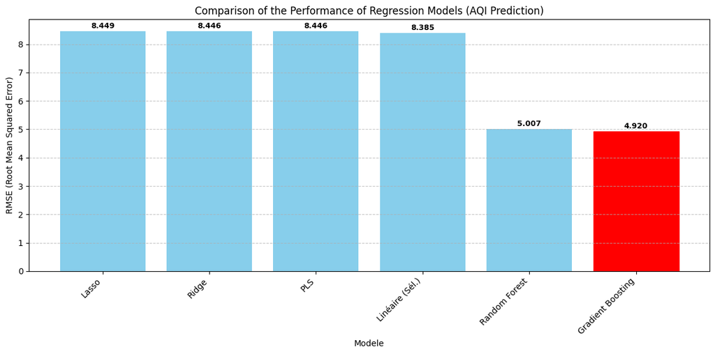

```python
plt.figure(figsize=(12, 6))
bars = plt.bar(reg_results['Modèle'], reg_results['RMSE'], color='skyblue')

best_model_reg_name = 'Gradient Boosting'
best_model_reg_index = reg_results[reg_results['Modèle'] == best_model_reg_name].index[0]

bars[best_model_reg_index].set_color('red')
for bar in bars:
    yval = bar.get_height()
    plt.text(bar.get_x() + bar.get_width()/2.0, yval + 0.05, f'{yval:.3f}', ha='center', va='bottom', fontsize=9, fontweight='bold')

plt.title('Comparison of the Performance of Regression Models (AQI Prediction)')
plt.ylabel('RMSE (Root Mean Squared Error)')
plt.xlabel('Modele')
plt.xticks(rotation=45, ha='right')
plt.grid(axis='y', linestyle='--', alpha=0.7)
plt.tight_layout()
plt.show()
```

About the picture we remark that the best model is Gradient Boosting

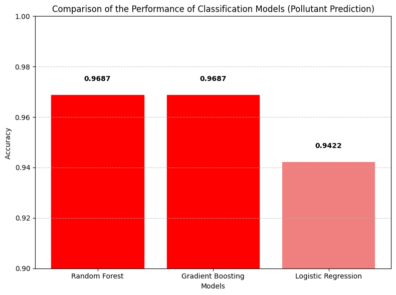

```
Chart Analysis :
1. 1. Regression: Gradient Boosting (RMSE 4.920) performs much better than linear models (RMSE around 8.4), showing that a non-linear approach is more suitable.
2. Classification: Ensemble models (Random Forest and Gradient Boosting Classifier) are clearly better (Accuracy 0.9687) than Logistic Regression (Accuracy 0.9422), which supports our final model choice.
```

```python
plt.figure(figsize=(8, 6))
bars_clf = plt.bar(clf_results['Model'], clf_results['Accuracy'], color='lightcoral')

max_acc = clf_results['Accuracy'].max()
for i, acc in enumerate(clf_results['Accuracy']):
    if acc == max_acc:
        bars_clf[i].set_color('red')


for bar in bars_clf:
    yval = bar.get_height()
    plt.text(bar.get_x() + bar.get_width()/2.0, yval + 0.005, f'{yval:.4f}', ha='center', va='bottom', fontsize=10, fontweight='bold')

plt.title('Comparison of the Performance of Classification Models (Pollutant Prediction)')
plt.ylabel('Accuracy ')
plt.xlabel('Models')
plt.ylim(0.9, 1.0)
plt.grid(axis='y', linestyle='--', alpha=0.7)
plt.tight_layout()
plt.show()

print("\nChart Analysis :")
print("1. 1. Regression: Gradient Boosting (RMSE 4.920) performs much better than linear models (RMSE around 8.4), showing that a non-linear approach is more suitable.")
print("2. Classification: Ensemble models (Random Forest and Gradient Boosting Classifier) are clearly better (Accuracy 0.9687) than Logistic Regression (Accuracy 0.9422), which supports our final model choice.")
```

```python
#!pip install tensorflow
```

### Conclusion

The performance comparison for AQI regression and pollutant classification shows that non-linear tree-based methods are clearly superior. Linear models (like Lasso and Ridge) reach their limit with an RMSE around 8.4 for AQI, confirming that the pollutant–AQI relationship is strongly non-linear.

Our final chosen model is Gradient Boosting. For AQI regression, it achieves an RMSE of 4.920 (with a 95% confidence interval for the True Test MSE of [21.274, 28.126]). For pollutant classification, it reaches an Accuracy of 0.9687. These results show that predictions are mainly driven by Fine Particles (PM2.5_AVG), which represent more than 90% of the predictive importance.

Looking ahead, adding clustering concepts (Smog, Traffic, Dust) and exploring a Deep Learning model such as an LSTM for short-term forecasting are promising next steps to turn these results into real environmental decision-making tools.